# Innovation Diffusion with the Bass Model: Dreame Pocket High-Speed Hair Dryer (U.S.)

Narek Nurijanyan

October 05, 2025

```r
knitr::opts_chunk$set(echo = TRUE, message = FALSE, warning = FALSE)
suppressPackageStartupMessages({
  library(tidyverse)
  library(readxl)
  library(ggplot2)
  library(broom)
})
```

Historical analogue is the Dyson Supersonic (launched 2016) which covered the premium, high-speed dryer segment with a compact digital motor, intelligent heat control and magnetic attachments(Vincent, 2016). Both innovations deliver fast drying from very high-velocity airflow generated by compact brushless motors and reduce heat damage via improved temperature control and ionization. Technologically, the Dreame Pocket inherits the high-RPM motor lineage while also having portability and 2-in-1 use (dry + style) in a folding form factor. Dyson re-created hair dryers as tech appliances consumers will pay a premium for and Dreame extends that premium proposition to travel and multifunction potentially enlarging the addressable premium niche by targeting on-the-go users.

3. Time series used: U.S. retail unit sales of hair dryers, 2010–2018 (millions). Statista. (2019). Retail unit sales of hair dryers in the United States from 2010 to 2018 (in millions). We use U.S. retail unit sales (2010–2018), U.S. household counts, and a U.S. launch context for Dreame.

```r
hd <- read_excel("data/Hair-Dryer.xlsx") %>%
  mutate(Year = as.integer(Year),
         Sales = as.numeric(Sales)) %>%
  arrange(Year) %>%
  mutate(t = row_number())

hd
```

| Year | Sales | t |
| --- | --- | --- |
| 2010 | 21.0 | 1 |
| 2011 | 21.0 | 2 |
| 2012 | 20.7 | 3 |
| 2013 | 19.6 | 4 |
| 2014 | 19.4 | 5 |
| 2015 | 19.2 | 6 |
| 2016 | 19.0 | 7 |
| 2017 | 19.4 | 8 |
| 2018 | 19.3 | 9 |

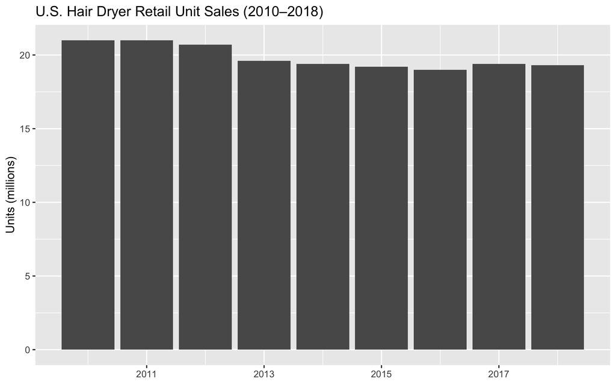

```r
ggplot(hd, aes(x = Year, y = Sales)) +
  geom_col() +
  labs(title = "U.S. Hair Dryer Retail Unit Sales (2010–2018)",
       y = "Units (millions)", x = NULL)
```

Sales are around ~19–21 million units per year with a mild downward drift. This stability signals that current volumes are driven mostly by replacement purchases, not fresh first-time adoption. This is important to know when fitting the Bass model

# Bass model: F(t) = M * (1 - exp(-(p+q)*t)) / [1 + (q/p)*exp(-(p+q)*t)]

```r
bass_F <- function(t, p, q) {
  (1 - exp(-(p+q)*t)) / (1 + (q/p) * exp(-(p+q)*t))
}

bass_a <- function(t, p, q, M) {
  A_t   <- M * bass_F(t, p, q)
  A_tm1 <- M * bass_F(pmax(t-1, 0), p, q)
  A_t - A_tm1
}
```

These functions implement the Bass model in closed form. We use them to compute cumulative adoption for estimation and forecasting.

```r
start_free <- list(p = 0.01, q = 0.10, M = 200)
fit_free <- nls(Sales ~ bass_a(t, p, q, M),
                data = hd,
                start = start_free,
                algorithm = "port",
                lower = c(0, 0, 0))
summary(fit_free)
```

```
##
## Formula: Sales ~ bass_a(t, p, q, M)
##
## Parameters:
##    Estimate Std. Error t value Pr(>|t|)
## p 1.310e-02  9.535e-02   0.137    0.895
## q 0.000e+00  1.073e-01   0.000    1.000
## M 1.606e+03  1.172e+04   0.137    0.895
##
## Residual standard error: 0.4617 on 6 degrees of freedom
##
## Algorithm "port", convergence message: relative convergence (4)
```

```r
coef(fit_free)
```

```
##            p            q            M
## 1.309888e-02 0.000000e+00 1.606016e+03
```

The free-M as q approaches to 0 it inflates M to very large values which is a known signal in saturated markets where sales mainly reflect replacements. This fit can match levels but is hard to interpret economically so we treat it as a diagnostic rather than our primary specification.

```r
M_fix <- 130
start_fixed <- list(p = 0.015, q = 0.005)
fit_fixed <- nls(Sales ~ bass_a(t, p, q, M_fix),
                 data = hd,
                 start = start_fixed,
                 algorithm = "port",
                 lower = c(0, 0))
summary(fit_fixed)
```

```
##
## Formula: Sales ~ bass_a(t, p, q, M_fix)
##
## Parameters:
##   Estimate Std. Error t value Pr(>|t|)
## p  0.08291    0.04550   1.822    0.111
## q  0.35943    0.22964   1.565    0.162
##
## Residual standard error: 8.667 on 7 degrees of freedom
##
## Algorithm "port", convergence message: relative convergence (4)
```

```r
coef(fit_fixed)
```

```
##          p          q
## 0.08291297 0.35943336
```

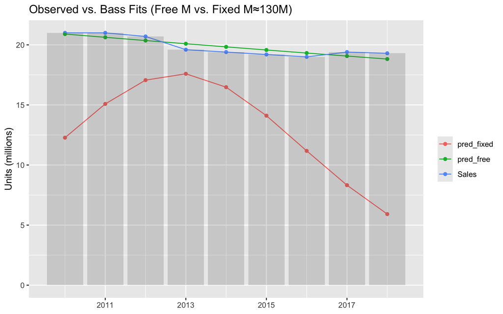

```r
hd_fit <- hd %>%
  mutate(pred_free  = bass_a(t, coef(fit_free)[["p"]],  coef(fit_free)[["q"]],  coef(fit_free)[["M"]]),
         pred_fixed = bass_a(t, coef(fit_fixed)[["p"]], coef(fit_fixed)[["q"]], M_fix))

hd_fit_long <- hd_fit %>%
  select(Year, Sales, pred_free, pred_fixed) %>%
  pivot_longer(-Year, names_to = "series", values_to = "value")

ggplot(hd_fit_long, aes(Year, value, color = series)) +
  geom_point() + geom_line() +
  geom_col(data = hd, aes(Year, Sales), inherit.aes = FALSE, alpha = 0.2) +
  labs(title = "Observed vs. Bass Fits (Free M vs. Fixed M≈130M)",
       y = "Units (millions)", x = NULL, color = NULL)
```

A conservative U.S. market potential for the Dreame Pocket can be set at ≈6 million households. The U.S. has about 132.7 million households (U.S. Census Bureau, 2024), and a Statista price-expectations survey reports that only ~6.1% of consumers are willing to pay $100+ for a hair dryer (Statista, 2021)—i.e., roughly 8.1 million premium-intent households at the category level. Because Dreame Pocket targets a compact/travel sub-segment within that premium tier and some of those buyers will choose full-size models or other brands. We adopt a conservative base 𝑀 = 6,000,000 for forecasting, which sits comfortably within the 5–8 million range implied by these data.

```r
p_hat <- as.numeric(coef(fit_fixed)[["p"]])
q_hat <- as.numeric(coef(fit_fixed)[["q"]])

M_dreame <- 6
horizon <- 20
years <- 1:horizon

dreame_new <- bass_a(years, p_hat, q_hat, M_dreame)
dreame_cum <- cumsum(dreame_new)

dreame_df <- tibble(
  Year = seq(2025, by = 1, length.out = horizon),
  New_Adopters_mln = dreame_new,
  Cumulative_Adopters_mln = dreame_cum
)

dreame_df %>% head(10)
```

| Year | New_Adopters_mln | Cumulative_Adopters_mln |
| --- | --- | --- |
| 2025 | 0.5666082 | 0.5666082 |
| 2026 | 0.6962379 | 1.2628460 |
| 2027 | 0.7876568 | 2.0505028 |
| 2028 | 0.8119337 | 2.8624365 |
| 2029 | 0.7605384 | 3.6229749 |
| 2030 | 0.6511124 | 4.2740873 |
| 2031 | 0.5158627 | 4.7899500 |
| 2032 | 0.3841805 | 5.1741305 |
| 2033 | 0.2731265 | 5.4472570 |
| 2034 | 0.1878258 | 5.6350828 |

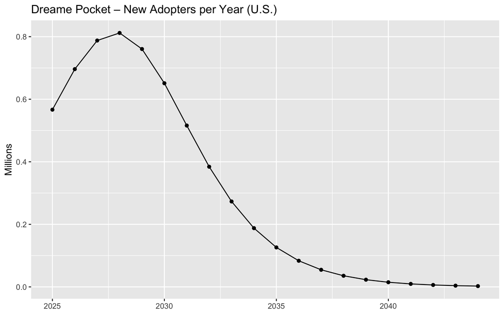

```r
p1 <- ggplot(dreame_df, aes(Year, New_Adopters_mln)) +
  geom_line() + geom_point() +
  labs(title = "Dreame Pocket – New Adopters per Year (U.S.)",
       y = "Millions", x = NULL)
p1
```

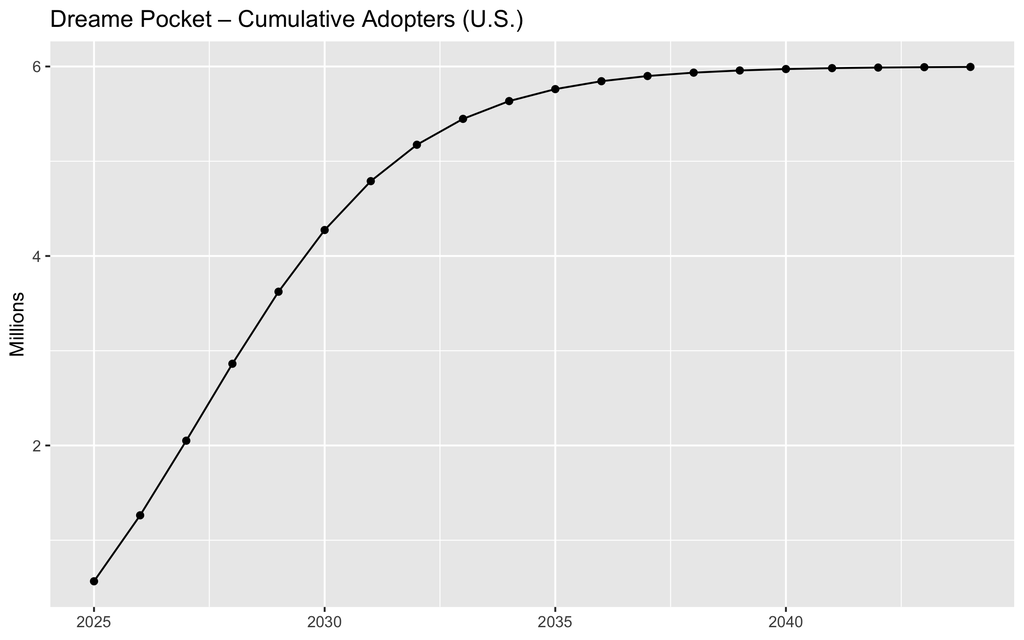

```r
p2 <- ggplot(dreame_df, aes(Year, Cumulative_Adopters_mln)) +
  geom_line() + geom_point() +
  labs(title = "Dreame Pocket – Cumulative Adopters (U.S.)",
       y = "Millions", x = NULL)

p2
```

```r
dreame_df %>%
  mutate(New_Adopters = round(New_Adopters_mln * 1e6),
         Cumulative_Adopters = round(Cumulative_Adopters_mln * 1e6)) %>%
  select(Year, New_Adopters, Cumulative_Adopters) %>%
  knitr::kable(format = "simple", align = "r")
```

| Year | New_Adopters | Cumulative_Adopters |
| --- | --- | --- |
| 2025 | 566608 | 566608 |
| 2026 | 696238 | 1262846 |
| 2027 | 787657 | 2050503 |
| 2028 | 811934 | 2862437 |
| 2029 | 760538 | 3622975 |
| 2030 | 651112 | 4274087 |
| 2031 | 515863 | 4789950 |
| 2032 | 384180 | 5174130 |
| 2033 | 273126 | 5447257 |
| 2034 | 187826 | 5635083 |
| 2035 | 126231 | 5761314 |
| 2036 | 83531 | 5844845 |
| 2037 | 54709 | 5899554 |
| 2038 | 35591 | 5935146 |
| 2039 | 23052 | 5958198 |
| 2040 | 14889 | 5973087 |
| 2041 | 9598 | 5982685 |
| 2042 | 6180 | 5988865 |
| 2043 | 3977 | 5992842 |
| 2044 | 2557 | 5995399 |

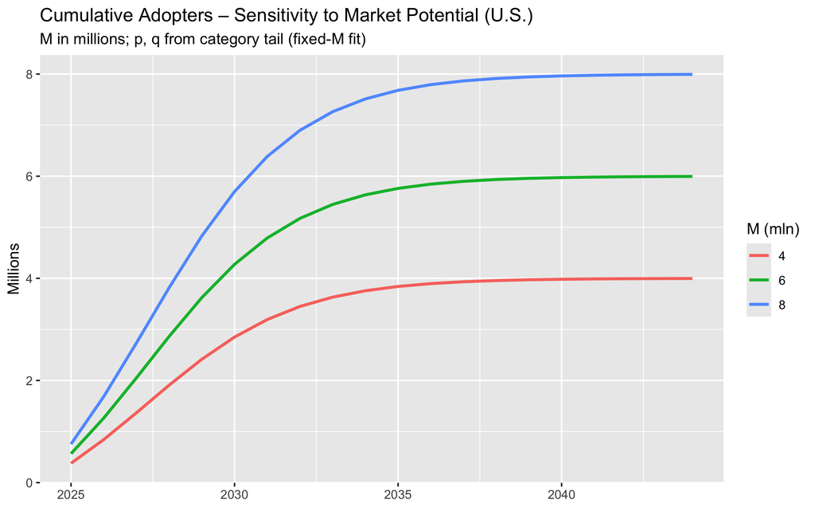

```r
M_grid <- c(4, 6, 8)
sens <- map_df(M_grid, function(Mi) {
  tibble(
    M = Mi,
    t = years,
    new = bass_a(years, p_hat, q_hat, Mi),
    cum = cumsum(bass_a(years, p_hat, q_hat, Mi))
  )
})

ggplot(sens, aes(t + 2024, cum, color = factor(M))) +
  geom_line(size = 1) +
  labs(title = "Cumulative Adopters – Sensitivity to Market Potential (U.S.)",
       subtitle = "M in millions; p, q from category tail (fixed-M fit)",
       y = "Millions", x = NULL, color = "M (mln)")
```